# The covidix package - an example

Marc Lavielle, Inria & Ecole Polytechnique

26 April, 2020

## Installation

Install covidix from GitHub:

```r
devtools::install_github("MarcLavielle/covidix")
```

Load the required R packages:

```r
library(covidix)
library(mlxR)
library(reshape2)
library(gridExtra)
library(dplyr)
library(tidyr)
library(ggplot2)
theme_set(theme_bw())
```

## Read the Johns-Hopkins University data

```r
args(rwCovid)
```

```
## function (file.out = NULL, data.correction = NULL)
## NULL
```

```r
d0 <- rwCovid()
```

The file “correction.csv” contains some corrected daily data for some countries (France & Spain) It is then possible to load this corrected data and use it with `rwCovid`

```r
f <- read.csv(url("https://raw.githubusercontent.com/MarcLavielle/covidix/master/correction.csv"))
head(f)
```

```
##   country       date day deaths confirmed
## 1  France 2020-04-02  72    471      2116
## 2  France 2020-04-03  73    588      5233
## 3  France 2020-04-04  74    441      4060
## 4  France 2020-04-05  75    357      2886
## 5  France 2020-04-06  76    595      3116
## 6  France 2020-04-07  77    607      3777
```

```r
d0 <- rwCovid(data.correction=f)
```

Write the data

```r
file.data <- "./covid19.csv"
write.csv(d0, file=file.data, quote=F, row.names = F)
```

## Select some data

```r
args(filterCovid)
```

```
## function (type = c("confirmed", "deaths"), country = NULL, file.in = NULL,
##     file.out = NULL, data = NULL, nc.min = 0, nd.min = 0, fc.min = 0,
##     fd.min = 0, day.max = Inf, day.min = 0)
## NULL
```

Select some countries

```r
countries <- c( "Japan", "France", "South Korea", "Italy", "Iran", "Spain", "Switzerland", "US", "China Hubei")
d.plot <- filterCovid(file.in=file.data, country=countries)
```

## Plot some data

```r
args(plotCovid)
```

```
## function (data = d, type = c("confirmed", "deaths"), nc.min = 200,
##     nd.min = 20, p.min = 0.005, point.size = 1, line.size = 0.75,
##     log.scale = TRUE, plot = FALSE)
## NULL
```

Plot the data for the selected countries

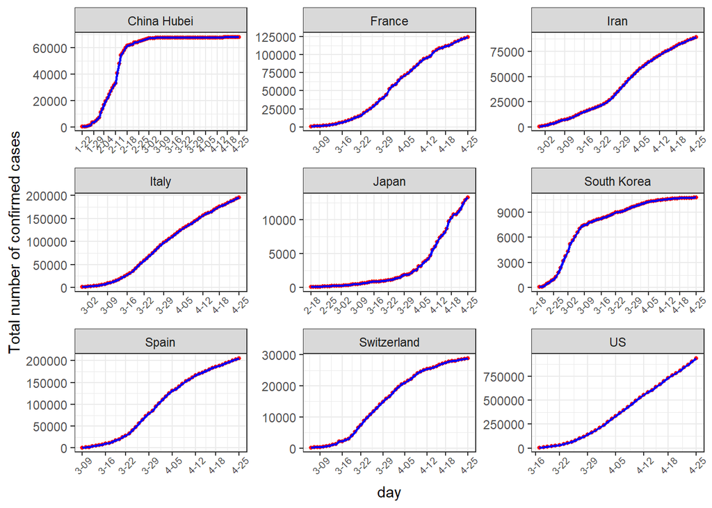

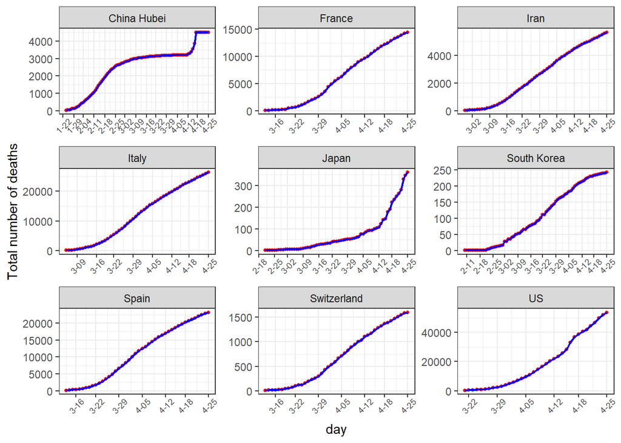

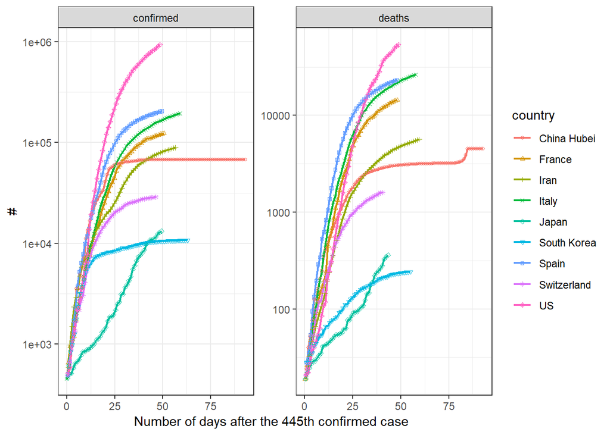

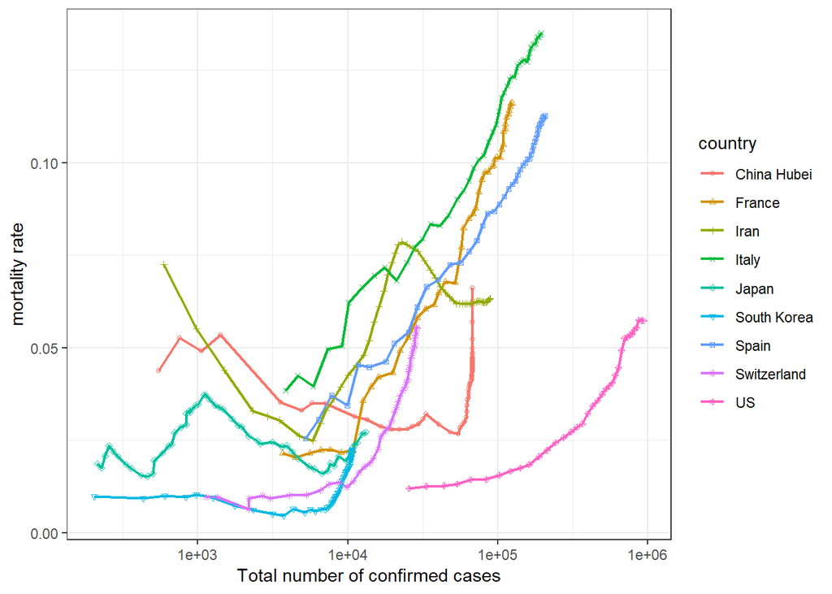

```r
pl <- plotCovid(data=d.plot)
print(pl)
```

## Short time mortality forecasting

```r
args(corfit)
```

```
## function (data = NULL, country = NULL, shift = NULL, log.scale = FALSE,
##     variable = c("total", "daily"), n.max = 7, p = 0, point.size = 1.5,
##     line.size = 0.75, predict = TRUE, interval = TRUE, level = 0.95,
##     nc.min = 100, nd.min = 5)
## NULL
```

The purpose of this function is to find the best time-lag between the series of cumulated cases and the series of cumulated deaths in order to superimpose them as well as possible. Then, a linear model provides an accurate prediction of the number of deaths for the next days.

We select the Italian data:

```r
d.italy <- filterCovid(file.in=file.data, nc.min=1000, nd.min=10, country="Italy")
r=corfit(data=d.italy)
print(r$coeff)
```

```
## shift scale
## 4.000 0.143
```

Plot the observed and predicted counts (daily and cumulated)

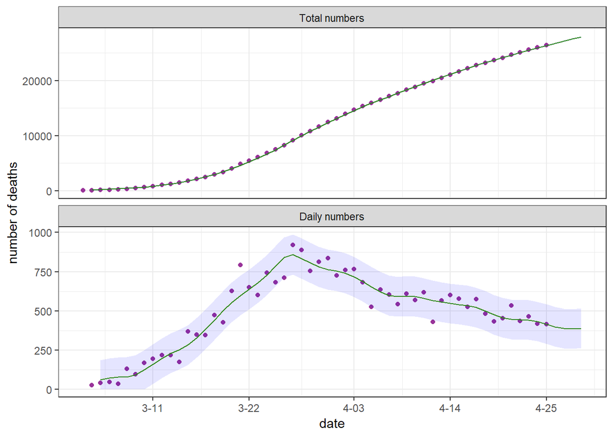

```r
print(r$plot)
```

## Fit the SIR-type model

```r
args(fitCovid)
```

```
## function (data = NULL, country = NULL, nb.day = 14, estim.tau = T,
##     estim.p0 = T, M = NULL, M.max = 3, d.tau = 6, l.tau = 6,
##     cw = c(1, 1, 1, 1), dir = ".", K1 = 5, ndt = 5)
## NULL
```

The SIR model described [here](http://webpopix.org/covidix19.html) is fitted to the data

```r
r <- fitCovid(data=d.italy)
```

```
##          pa1      pb1
## DEV 2913.932 2898.840
## BIC 2970.766 2979.356
```

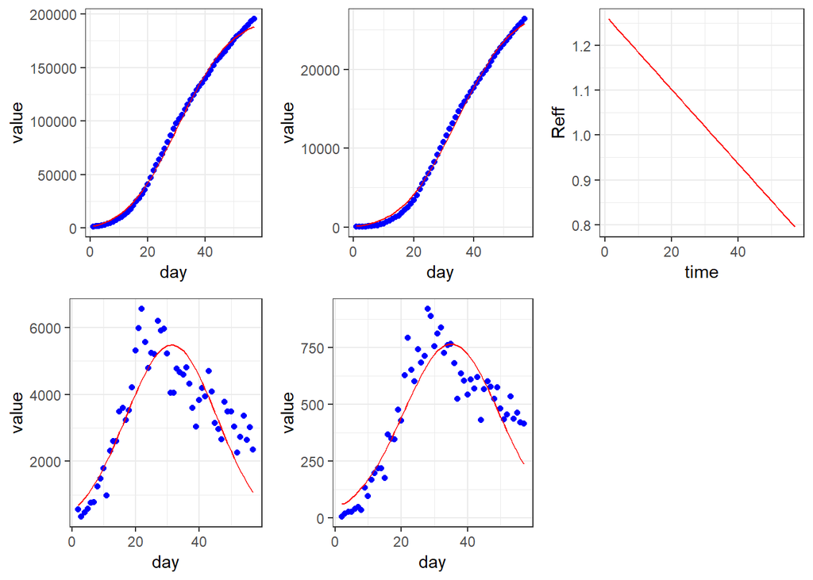

```
## [1] 2
```

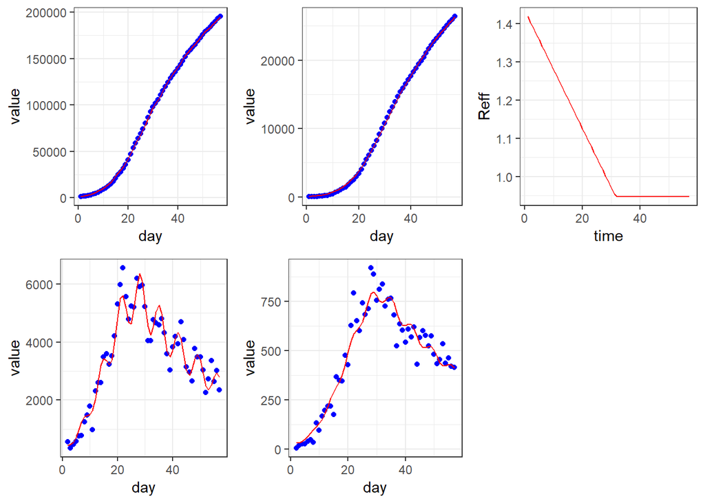

```
## tau1
## 31.5
##            pA       pB
## DEVM 2580.205 2518.715 2548.364 2514.016
## BICM 2641.775 2603.967 2614.671 2604.004
## [1] 3
```

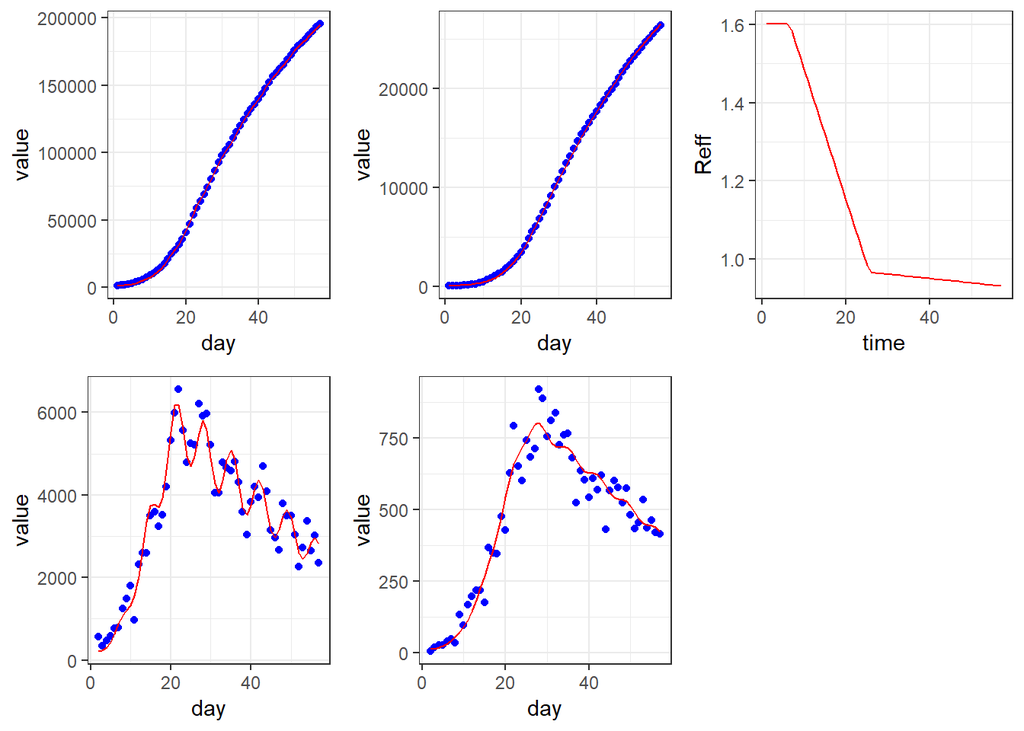

```
## tau1 tau2
##  6.5 25.5
##            pA       pB
## DEVM 2521.430 2468.850 2470.760 2420.699 2513.505 2468.816 2470.096
## BICM 2587.737 2558.838 2541.803 2515.423 2584.548 2563.540 2545.876
##
## DEVM 2453.061
## BICM 2552.521
##      pa1      pb1       pA       pB                         pA       pB
## 2970.766 2979.356 2641.775 2603.967 2614.671 2604.004 2587.737 2558.838
##
## 2541.803 2515.423 2584.548 2563.540 2545.876 2552.521
```

## Plot the results

```r
args(fitPlot)
```

```
## function (country = "France", file = NULL, file.test = NULL,
##     nb.day = 2, plot.tau = F, plot.pred = T, plot.pred0 = T,
##     plot.day = T, log.scale = F, level = 0.9, pred.int = F, conf.int = F)
## NULL
```

Plot the selected model with the data and the effective reproduction number $R_{\rm eff}$

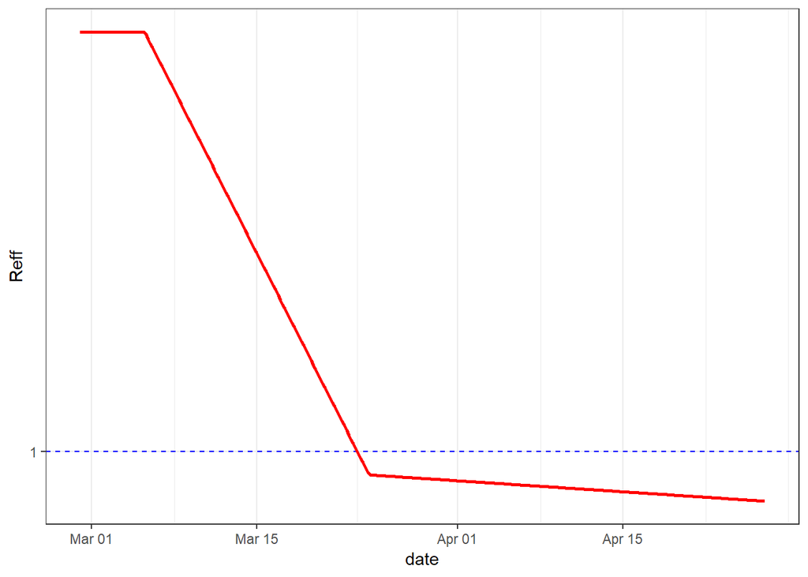

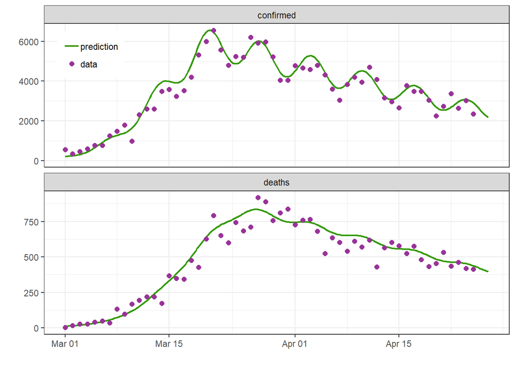

```r
print(fitPlot(file=r$file))
```

Add a prediction interval (only the residual error is used here, not the uncertainty on the parameter estimation)

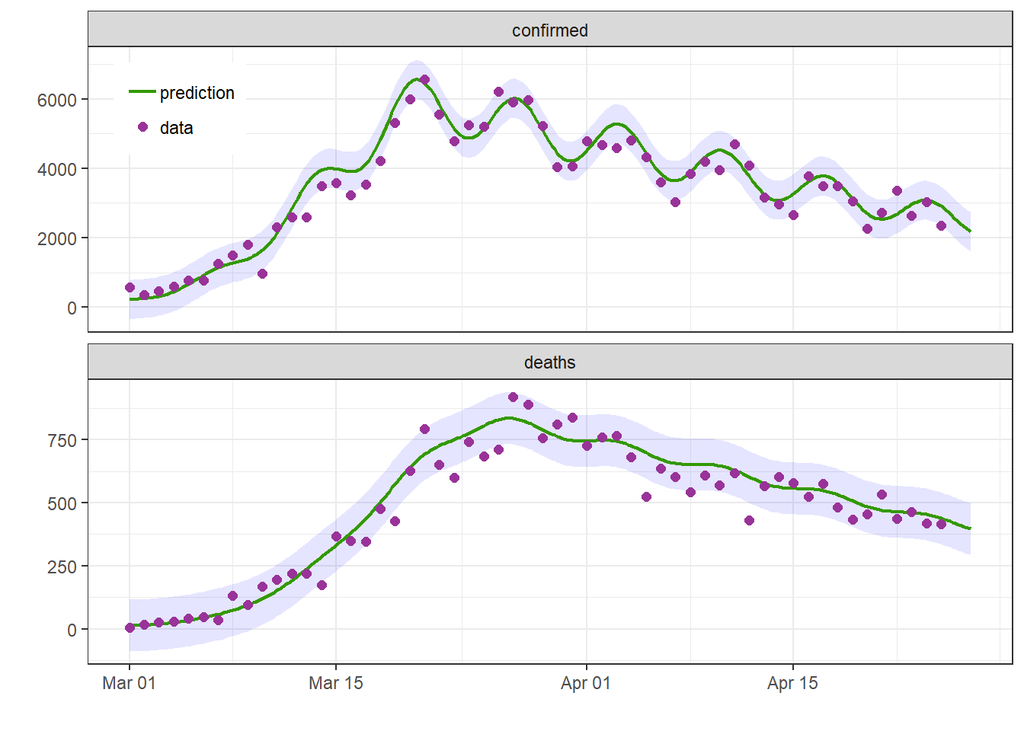

```r
print(fitPlot(file=r$file, pred.int=T)[[2]])
```